Status: Draft — work in progress

# What the H3K27ac and ATAC data are, and what is predictable from them

2026-09-05

## Headline figure

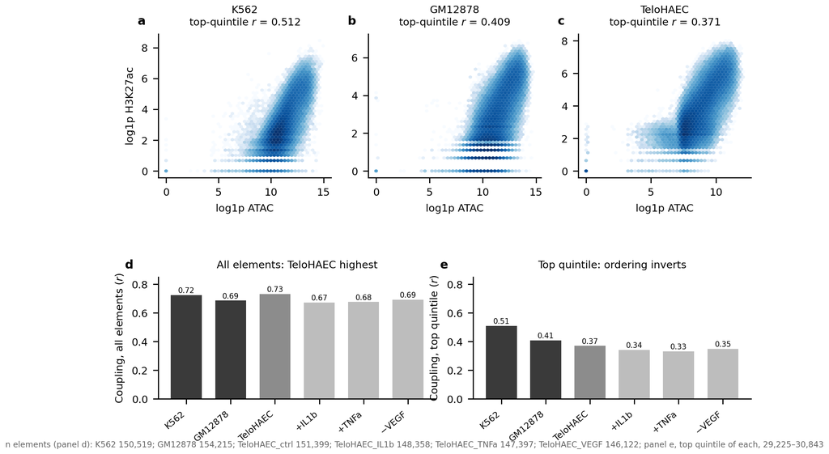

**Figure 1 | How much of H3K27ac accessibility can explain is a property of the cell type, and the ordering inverts between strata.** **Headline figure.**

**Full legend**

See the coupling section below for the complete legend. The two points that make this the headline: the model-free ATAC-H3K27ac correlation on the elements carrying the mark is 0.51 in K562 against 0.33-0.41 in every other cell type measured, so an accessibility-based number is not comparable across cell types without this denominator, and on all elements the ordering inverts, with TeloHAEC highest, because that stratum is dominated by the dead-versus-active contrast every accessible-element set shares. Source: `results/atac_vs_h3k27ac_by_celltype.tsv`, `results/coupling_panel_recomputed.tsv`.

## Goals

This report records what the H3K27ac and ATAC data *are*, and what is predictable from them in principle, separately from any model. It exists so that the other two reports can cite a ceiling, a coupling or a track definition without re-deriving it, and so that a number quoted anywhere in the project can be checked against the measurement it came from. Every ceiling in the project lives here.

Three companion documents:

- **Report 2, evaluation methodology**: how a comparison in this project is scored and what each metric can and cannot support. Standing cautions, each with the incident that motivated it.
- **Report 3, design decisions**: the workbench. Which architecture and input changes were tried, what each did to the reporting metric, and the verdict.
- `reference/DATA_INVENTORY.md`: the full assay inventory across all nine cell types, including which assays exist where and which files must not be used.

## Datasets

| Dataset | Assay / system | Source | Used as |
| --- | --- | --- | --- |
| **K562 H3K27ac** | H3K27ac ChIP-seq, single-end 36 bp, 2 replicates (ENCFF790GFL, ENCFF817HMW) | ENCODE ENCSR000AKP | Prediction target |
| **K562 ATAC-seq** | ATAC-seq, paired-end, 3 replicates (ENCFF077FBI, ENCFF128WZG, ENCFF534DCE) | ENCODE ENCSR868FGK | Accessibility input |
| **K562 candidate elements** | DNase-derived candidate regulatory elements, n = 150,528, mean width 608 bp | Repo: `reference/K562_DNase_candidate_elements.narrowPeak` | Coordinate system; windows centred on element midpoints |
| **GM12878 H3K27ac** | H3K27ac ChIP-seq, single-end, 2 replicates (ENCFF645BAL, ENCFF865OOP) | ENCODE | Cross-cell-type evaluation target |
| **GM12878 ATAC-seq** | ATAC-seq | ENCODE; repo: `2026_0606_GM12878_transferability/data/atac.bw` | Accessibility input for transfer |
| **GM12878 candidate elements** | Candidate regulatory elements, n = 154,224 | Repo: `2026_0606_GM12878_transferability/reference/` | Transfer coordinate system |
| **K562 p300** | EP300 ChIP-seq, stranded | ENCODE ENCSR000EGE | Reference target for the sequence-margin comparison |
| **K562 DNase** | DNase-seq, ENCSR000EOT (pe + se), and ENCSR000EKS (se); 301.1M usable reads | ENCODE | Alternative accessibility input |
| **GM12878 DNase** | DNase-seq, ENCSR000EMT (se); 53.8M usable reads, 9.5% chrM, count ceiling 0.445 on the top quintile | ENCODE | Alternative accessibility input, materially weaker than K562’s |
| **hg38 CV folds** | Chromosome-holdout 5-fold split | Repo: `reference/hg38_five_folds.json` | Shared across all models so numbers are comparable |
| **Training negative pool** | ChromBPNet genome-wide GC-*annotated* tiling, hg38; n = 3,088,298 bins, 1 kb stride, mean GC 0.389. **Not GC-matched to the positives**, see the negatives section below | Repo: `reference/genomewide_gc_stride_1000_flank_size_1057.gc.bed` | Training negatives only; never evaluated on |

All ChIP-seq targets are counted as **5’ read ends** at single-base resolution (`bedtools genomecov -5 -dz`, stranded), matching the convention already used for the p300 models in this repository. Model architecture is `MultiModalBPNet` (`scripts/multimodal_bpnet.py`), a BPNet variant with a profile head and a counts head; only the counts head is analysed here. All correlations are on log counts.

## Accessibility explains less of H3K27ac outside K562, and the strata disagree about the ordering

**Q:** Is the ATAC-only model’s lower score in GM12878 a failure to generalise, or is accessibility less coupled to H3K27ac there?

**A:** Accessibility is less coupled there, the model-free ATAC-H3K27ac correlation is 0.409 in GM12878 against 0.510 in K562, while the ATAC-only model extracts a larger fraction of that available signal in GM12878 (ratio 1.14) than in K562 (1.06).

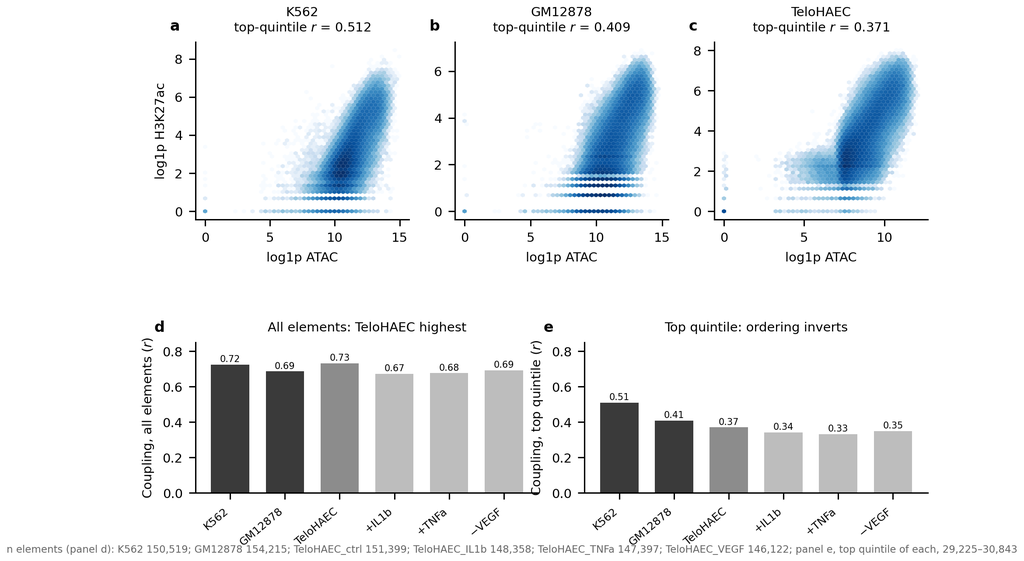

**Figure 1 legend**

**Figure 1 | Accessibility-H3K27ac coupling weakens outside K562.** **a-c**, log1p summed ATAC against log1p summed H3K27ac over identical +/-500 bp element-centred windows, one panel per cell type; colour is element density on a log scale. No model is involved, so these bound what any accessibility-only predictor could reach. Top-quintile Pearson **0.512 (K562), 0.409 (GM12878), 0.371 (TeloHAEC)**, on n = 150,519 / 154,215 / 151,399 elements. The x-range differs in **c** because the TeloHAEC ATAC library is shallower; correlation is unaffected by that scale. **d, e**, Coupling across all six cell types and conditions measured so far, on all elements (**d**), and the top signal quintile (**e**). **The ordering inverts between the two.** On all elements TeloHAEC scores highest (0.73), and every cell type sits within 0.06 of the others, because that stratum is dominated by the dead-versus-active contrast every accessible-element set shares. On the top quintile the range triples and K562 stands clear at 0.51 against 0.33-0.41 elsewhere. The top quintile is the informative stratum, and the contrast between **d** and **e** is why this report stratifies throughout. Placing the ATAC-only model against the top-quintile reference:

|  | K562 | GM12878 |
| --- | --- | --- |
| model-free ATAC-H3K27ac coupling | 0.510 | 0.409 |
| ATAC-only model | 0.542 | 0.467 |
| model / coupling | 1.06 | 1.14 |

The ATAC-only model does not degrade across cell types (it exceeds the raw coupling in both, by a wider margin in GM12878), so its lower absolute score there is a property of the assay pair. Sequence-only falls 0.360 -> 0.146 with no analogous denominator to absorb it. This sharpens the transfer conclusion: accessibility transfers, only sequence collapses. K562 and GM12878 use the same 5’ target processing and window; TeloHAEC uses its read-1-only equivalent. Sources: `results/atac_vs_h3k27ac_by_celltype.tsv`, `results/coupling_panel_recomputed.tsv`.

**Method.**

- Summed ATAC against summed H3K27ac over identical element windows; no model.
- Reported on the top H3K27ac quintile, matching every other evaluation here.

**Full methods & code**

This is the model-free reference for the ATAC-only baseline: it separates how much accessibility can explain in principle from how well a network learns it. Both are needed to read a cross-cell-type comparison, because the coupling is the denominator that makes accessibility-based numbers comparable between cell types. Results accumulate one row-set per label into a single TSV, so the panel extends by one invocation per cell type.

```bash
pixi run python scripts/0.12.atac_vs_h3k27ac.py --label K562 \
    --elements reference/K562_DNase_candidate_elements.narrowPeak \
    --atac-bw .../atac.bw \
    --h3k27ac-bw data/h3k27ac_5p_plus.bw,data/h3k27ac_5p_minus.bw \
    --outdir results --figdir figures
```

Source: `scripts/0.12.atac_vs_h3k27ac.py`

## H3K27ac sits on flanking nucleosomes and is far broader than ATAC

**Q:** Are ATAC and H3K27ac located in the same place relative to a candidate element?

**A:** No, ATAC peaks on the element centre (offset −12 bp, no dip), while H3K27ac is bimodal with shoulders at +/-250 bp and is far broader, still at 28% of maximum at +/-2 kb where ATAC has fallen to 17%.

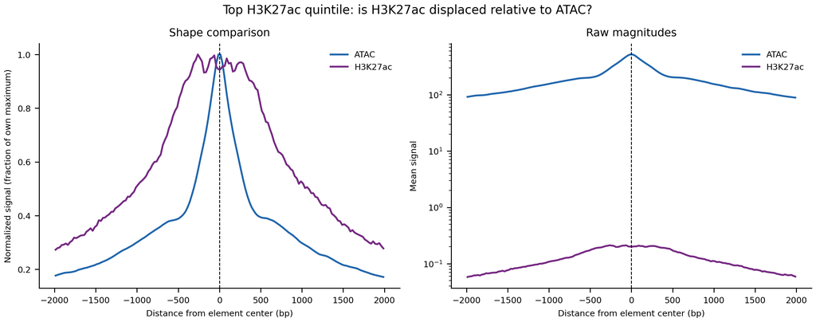

**Figure 2 legend**

**Method.**

- Meta-profiles binned at 50 bp over +/-2 kb, restricted to the top H3K27ac quintile.
- All tracks profiled on the identical element set; each normalised to its own maximum.

**Full methods & code**

Windows are centred on the candidate-element midpoint. The `summit` column of `K562_DNase_candidate_elements.narrowPeak` equals `width/2`, so element-centred windows require no change to the extraction code. Elements within `flank` of a contig end are dropped. Signal is read with pyBigWig and `nan` treated as zero.

```bash
pixi run python scripts/0.6.compare_profiles.py \
    --elements reference/K562_DNase_candidate_elements.narrowPeak \
    --track "ATAC:.../atac.bw" \
    --track "H3K27ac (5-prime):data/h3k27ac_5p_plus.bw,data/h3k27ac_5p_minus.bw" \
    --stratify-by "H3K27ac (5-prime)" --outdir results --figdir figures
```

Source: `scripts/0.6.compare_profiles.py`

## A 1 kb counting window is the best trade-off between signal and neighbour contamination

**Q:** How wide should the window be over which H3K27ac counts are summed?

**A:** +/-500 bp, wider windows raise the achievable ceiling only marginally (0.760 -> 0.798 from +/-500 to +/-2000), while the fraction of elements containing a *different* candidate element rises from 0% to 41.5%.

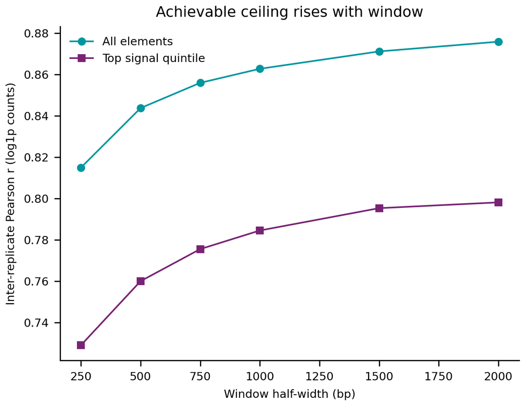

**Figure 3 legend**

**Figure 3 | The achievable ceiling saturates by +/-1 kb, while neighbour contamination keeps rising.** Inter-replicate Pearson correlation of log H3K27ac counts between the two ENCSR000AKP replicates, as a function of the half-width of the symmetric counting window, over all n = 150,526 candidate elements (teal), and the top signal quintile (purple). Because the two replicates measure the same biology, their agreement bounds how well any model can predict the merged target. Top-quintile values: 0.729 (+/-250 bp), 0.760 (+/-500), 0.776 (+/-750), 0.785 (+/-1000), 0.795 (+/-1500), 0.798 (+/-2000). The countervailing cost is neighbour contamination, the fraction of elements with another candidate element’s centre inside the window, which is a property of element spacing and independent of the assay: 0% at +/-250 and +/-500 bp, 9.9% at +/-750, 19.9% at +/-1000, 33.1% at +/-1500, 41.5% at +/-2000 (`results/window_tradeoff.tsv`). A contaminated window’s count is not attributable to the element it is centred on, which matters for any subsequent sequence-attribution work. +/-500 bp is the widest window with zero contamination. Source: `results/fiveprime_replicate_ceiling_by_window.tsv`.

**Method.**

- Per-replicate 5’-end BigWigs built with identical processing to the merged training target.
- Neighbour contamination computed from element-centre spacing per chromosome.

**Full methods & code**

Ceilings are reported as the raw inter-replicate *r*. Converting to a bound on model performance requires two corrections, applied wherever a fraction-of-ceiling is quoted in this report: Spearman-Brown for the fact that the model predicts the two-replicate *merge* rather than one replicate (`rel = 2r/(1+r)`), then a square root, since a model predicts the expected signal while a replicate is one noisy realisation of it. At +/-500 bp this converts a raw 0.760 into a bound of 0.929 on the top quintile, and a raw 0.844 into 0.957 over all elements.

A separate test asked whether excluding the nucleosome-free centre sharpens the target, on the reasoning that H3K27ac is deposited on the flanks. It does not: excluding +/-125/+/-250/+/-375 bp lowers the top-quintile ceiling monotonically (0.760 -> 0.747 -> 0.729 -> 0.717), because the shallow central dip means the centre still carries ~94% of peak signal, so excluding it discards real reads. The flanking-only count also correlates 0.93-0.99 with the full-window count, so the two targets are barely different. Full symmetric window retained (`results/flanking_vs_full_window.tsv`).

```bash
pixi run python scripts/0.3.replicate_ceiling_by_window.py \
    --elements reference/K562_DNase_candidate_elements.narrowPeak \
    --rep1-bw data/h3k27ac_rep1_5p_plus.bw,data/h3k27ac_rep1_5p_minus.bw \
    --rep2-bw data/h3k27ac_rep2_5p_plus.bw,data/h3k27ac_rep2_5p_minus.bw \
    --outdir results --figdir figures --label fiveprime_
pixi run python scripts/0.4.flanking_vs_full.py --outer 500 1000 --inner 0 125 250 375
```

Source: `scripts/0.3.replicate_ceiling_by_window.py`, `scripts/0.4.flanking_vs_full.py`

## H3K27ac has no reproducible base-resolution profile

**Q:** Is there base-resolution structure in the H3K27ac profile for the 1 bp profile head to learn, and if not, at what bin size does reproducible structure appear?

**A:** A perfect model caps at *r* = 0.21 in K562 and 0.18 in GM12878 on the top quintile at 1 bp, rising to 0.72 and 0.70 when binned to 50 bp and 0.79 and 0.78 at 100 bp, so the base-resolution multinomial term is largely fitting Poisson noise.

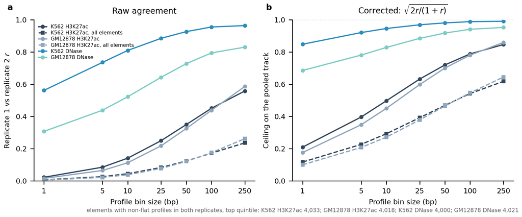

**Figure 4 legend**

**Method.**

- Within-element correlation across positions removes the count signal, which the count ceiling already covers.
- Elements flat in either replicate are excluded rather than scored as 0, which would conflate unreproducible with no-shape-to-reproduce.
- 500 bp is omitted: a 1 kb window gives 2 bins, too few for a within-element correlation.

**Full methods & code**

```bash
sbatch scripts/0.25.submit.sh
```

Source: `scripts/0.25.profile_ceiling_by_binsize.py`

## The ATAC library supports fragment-size stratification

**Q:** Does the K562 ATAC data contain a usable mono-nucleosomal population?

**A:** Yes, a clean nucleosomal ladder with a sub-nucleosomal mode at 42 bp and mono-nucleosomal peak at ~205 bp, though the two currently-built channels capture only 50% of fragments.

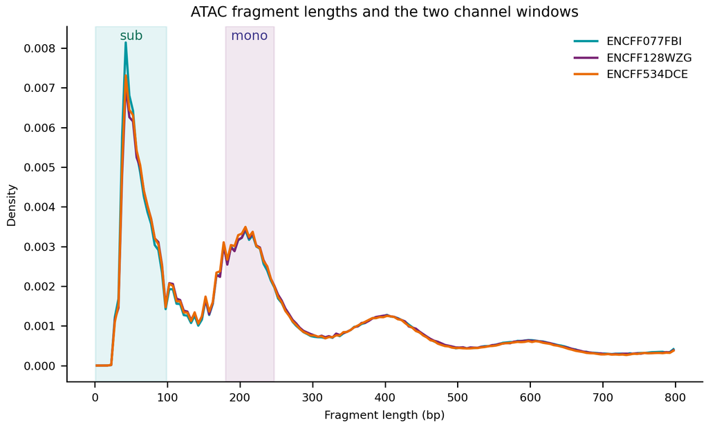

**Figure 5 legend**

**Figure 5 | K562 ATAC fragment lengths show clear nucleosomal laddering.** Fragment-length density from TLEN of properly-paired reads, chr1, ~1.4 million fragments per replicate, three ENCSR868FGK replicates overlaid (ENCFF077FBI, ENCFF128WZG, ENCFF534DCE). Sub-nucleosomal mode at 42 bp, mono-nucleosomal peak at ~205 bp, di-nucleosomal at ~400 bp and tri-nucleosomal at ~600 bp; median 201 bp; replicates superimpose. Shaded bands are the two channel windows built so far: sub-nucleosomal 1-99 bp (30.3% of fragments), and mono-nucleosomal 180-247 bp (19.7%), leaving **50.0% of fragments in neither**, the 100-180 bp trough and everything above 247 bp, including both higher-order peaks. A four-channel design of [all fragments, sub, mono, di] would make the input a strict superset of the current flat-accessibility baseline, so it cannot regress, while adding the higher-order structure the ladder shows is present. Source: `results/atac_fragment_length_summary.tsv`.

**Method.**

- TLEN from properly-paired reads; each pair counted once via positive TLEN.
- Fragment lengths require the paired-end BAMs; the Tn5 tagAlign files are per-read and lose them.

**Full methods & code**

```bash
pixi run python scripts/0.10.plot_fragment_lengths.py \
    --bams $SCRATCH/atac_pe/ENCFF077FBI.pe.bam $SCRATCH/atac_pe/ENCFF128WZG.pe.bam \
           $SCRATCH/atac_pe/ENCFF534DCE.pe.bam \
    --outdir results --figdir figures
```

Source: `scripts/0.10.plot_fragment_lengths.py`, `scripts/0.9.make_atac_fragment_channels.sh`

## DNase cut sites are reproducible at base resolution

**Q:** H3K27ac has almost no reproducible 1 bp profile, which caps what any profile head can score. Does DNase behave the same way, or are cut sites reproducible where acetylation is not?

**A:** Reproducible, by roughly a factor of four. The 1 bp top-quintile ceiling is **0.848** in K562 and **0.686** in GM12878, against 0.21 and 0.18 for H3K27ac in the same cell types and by the same method (Fig. 4).

| 1 bp, top quintile | DNase | H3K27ac |
| --- | --- | --- |
| K562 | 0.848 | 0.21 |
| GM12878 | 0.686 | 0.18 |

K562 DNase saturates quickly: 0.921 at 5 bp and 0.946 at 10 bp, so a model predicting DNase at 5-10 bp rather than 1 bp would give up almost nothing.

**Why this matters beyond characterisation.** An ATAC-to-DNase converter has to emit something the downstream model can consume, and that model reads accessibility as a base-resolution 5’ insertion track. A converter predicting only per-element DNase counts and painting them flat would strip the structure the accessibility branch uses. These ceilings say the profile is there to be predicted, which makes the profile head the decisive component of a converter, having been near-useless everywhere else in this project.

**The two DNase libraries are not of equal quality, and the gap is large.** The count ceiling over the same +/-500 bp windows is *r* = 0.925 in K562 and **0.445** in GM12878 on the top quintile. Usable depth on the main chromosomes is 301.1M reads for K562 against 53.8M for GM12878, a 5.6x gap, where the two cell types’ ATAC libraries are matched at 545.7M and 571.4M. GM12878’s DNase also carries 9.5% mitochondrial reads against K562’s 0.075%.

Any DNase-versus-ATAC comparison in GM12878 therefore confounds assay with library quality, and a cross-cell-type DNase comparison confounds it with a 5.6x depth difference. The K562 in-cell comparison is the clean one, and it is conservative: DNase is the *shallower* input there (301.1M against ATAC’s 545.7M), so a DNase advantage would hold despite the handicap.

**Method.**

- Same script and same procedure as the H3K27ac ceilings, so the numbers sit on one scale: within-element correlation across positions between two replicates, which removes the count signal and leaves shape.
- Stranded per-replicate 5’ tracks, read 1 only for paired BAMs, detected per file rather than read from the metadata table.

**Full methods & code**

**A recorded constraint says mixed run types make an inter-replicate ceiling uncomputable**, which is why HCT116’s H3K27ac was excluded. K562’s ENCSR000EOT is listed as pe + se, so that objection applies here in principle. It is weaker under 5’ counting, which takes one cut site per read regardless of length and uses read 1 only for paired data, making a PE and an SE library comparable at the cut-site level. GM12878’s ENCSR000EMT is two clean SE replicates and was run as the control: it gives the same shape of curve, so the mixed run type is not generating K562’s result. K562’s replicates agree *better* (0.562 at 1 bp on the top quintile) than GM12878’s two matched SE replicates do (0.307).

```bash
sbatch scripts/0.33.dnase_profile_ceiling.sh
```

Source: `scripts/0.33`, `scripts/0.25.profile_ceiling_by_binsize.py`, `results/profile_ceiling_binsize_{k562,gm12878}_dnase.tsv`

## Accessibility track conventions, and the read-length confound they hide

Two conventions are in play for the accessibility input and they are different quantities.

**Full-interval coverage** (`bedtools genomecov -bg` over the tagAlign interval) counts `read_length` bases per read, so the track scales with read length and smears each Tn5 insertion across ~95 bases in our K562 and GM12878 libraries.

**5’ insertion counts** (`genomecov -bg -5`) count exactly one base per read, which is the ChromBPNet convention (`chrombpnet/helpers/preprocessing/reads_to_bigwig.py`: `-bg -5`, unstranded, ATAC shift `4-plus_shift, -4-minus_shift`). Our tagAligns are already Tn5-shifted, so the correct build reduces to adding `-5`; applying the shift again would double-shift.

The 5’ tracks are read-length independent by construction and are the correct choice the moment a third cell type enters. What the switch does to model performance is a design decision, not a property of the data, and is reported in Report 3.

## Element derivation differs between cell types, which is a standing confound

Documented in full in `reference/ELEMENT_DERIVATION.md`. The K562 and GM12878 candidate element sets are DNase-derived; TeloHAEC’s are ATAC-derived. TeloHAEC is therefore the one cell type whose elements match its own input assay, and the two cell types carrying most of this project’s results do not.

An ATAC-derived K562 set exists (`reference/K562_ATAC_candidate_elements.narrowPeak`, same rE2G model type as TeloHAEC’s), so the confound is testable rather than merely noted; the test and its result are in Report 3. The ABC candidate regions used for the downstream benchmark are ATAC-derived, from observed K562 ATAC.

## The training negative pool is not GC-matched, despite its filename

`reference/genomewide_gc_stride_1000_flank_size_1057.gc.bed` is ChromBPNet’s genome-wide GC-*annotated* tiling: 3,088,298 bins at 1 kb stride with GC in column 4. That file is the *input* to GC matching, not its output. Our training code reads only columns 1-3, discarding the GC column, and the sampler draws uniformly at random from a 50,000-window random subsample of it. So the training negatives are a uniform random sample of the genome, at mean GC **0.389** against **0.466-0.593** for candidate elements, and no matching to either cell type’s positive set takes place. The same pool is used for K562 and GM12878, which would be wrong if matching were happening (since the positives differ per cell type), and is moot because it is not.

What follows:

- **Negatives are not mislabelled.** They carry their *true* extracted H3K27ac signal rather than a hard zero, so the 1 kb bins that happen to overlap a real candidate element get their real signal. They are also restricted to each fold’s training chromosomes.
- **No reported number is computed on them.** Evaluation runs on the candidate element set only (Report 2), so every correlation in these three reports is an element-only number.
- **It was a plausible cause of the sequence branch’s flatness, and it is not the cause.** A positive/negative contrast separable on GC alone is a known way to turn a BPNet-style sequence branch into a coarse GC detector, and negatives are 10% of every batch differing from positives by ~0.1 in mean GC. **Tested and refuted**: retraining on properly GC-matched negatives gives +0.001 in-cell type (*p*=0.76), and -0.002 transferred (*p*=0.33), with the match verified beforehand, mean-GC gap to the elements closed 6.6x and the largest per-bin discrepancy 5x (Report 3). So the mismatch is real and documented here for anyone reproducing the training, but it is not decisive for any result.

**Practical consequence for reproduction.** Nothing needs re-running on account of the unmatched pool. If you build new models, `data/gc_negatives_{k562,gm12878}_h3k27ac.bed` are matched sets produced by `scripts/0.28`; they change nothing measurable, and using the tiling directly keeps new numbers comparable to every existing one. Failure modes of the matching tool are recorded in the repository learnings; it exits 0 having written nothing when `bedtools` is absent, and it hangs rather than reporting a shortfall when the foreground is GC-rich enough to exhaust the high-GC bins.

**Separately, the candidate element set itself spans active and inactive elements**, so most of it carries no H3K27ac whatever the negatives are doing. That is the reason every evaluation in this project is stratified, and it is independent of the issue above.

## Methods

All ChIP-seq targets are counted as **5’ read ends** at single-base resolution (`bedtools genomecov -5 -dz`, stranded), matching the convention already used for the p300 models in this repository. Accessibility inputs exist in both conventions described above; which one a given result used is recorded per result in `results/TARGET_PROVENANCE.md`.

Ceilings are reported as the raw inter-replicate *r*. Converting one to a bound on model performance requires two corrections, applied wherever a fraction-of-ceiling is quoted anywhere in this project: Spearman-Brown for the fact that the model predicts the two-replicate *merge* rather than one replicate (`rel = 2r/(1+r)`), then a square root, since a model predicts the expected signal while a replicate is one noisy realisation of it. At +/-500 bp this converts a raw 0.760 into a bound of 0.929 on the top quintile, and a raw 0.844 into 0.957 over all elements.

Windows are centred on candidate-element midpoints rather than summits, because the H3K27ac summit sits on a flanking nucleosome (Fig. 2). The `summit` column of `K562_DNase_candidate_elements.narrowPeak` equals `width/2`, so element-centred windows require no change to the extraction code. Elements within `flank` of a contig end are dropped. Signal is read with pyBigWig and `nan` treated as zero.

### Regenerate

```
Environment: pixi env `multimodal`, pixi.lock sha256:069960d36312
```

```bash
# Target and accessibility tracks
sbatch scripts/0.5.make_5prime_bigwigs.sh            # K562 H3K27ac 5' ends, merged + per-replicate
sbatch scripts/0.7.make_gm12878_5prime.sh            # GM12878 H3K27ac 5' ends
pixi run bash scripts/0.20.make_atac_5prime_bigwigs.sh
pixi run python scripts/0.21.validate_atac_5prime.py   # ratio == mean read length
sbatch scripts/0.22.calibrate_tn5_shift.sh
PLUS_DELTA=4 MINUS_DELTA=-5 sbatch scripts/0.23.make_atac_fragment_5p_channels.sh
pixi run python scripts/0.24.validate_atac_fragment_channels.py

# Characterisation
pixi run python scripts/0.6.compare_profiles.py   ...           # Fig 2
pixi run python scripts/0.3.replicate_ceiling_by_window.py ...  # Fig 3
pixi run python scripts/0.4.flanking_vs_full.py --outer 500 1000 --inner 0 125 250 375
sbatch scripts/0.25.submit.sh                                   # Fig 4
pixi run python scripts/0.10.plot_fragment_lengths.py ...       # Fig 5
pixi run python scripts/0.12.atac_vs_h3k27ac.py --label K562 ...  # Fig 1

# This report
python render_report.py report1_data_characterisation.qmd
```

Per-result provenance, including which processing of the target each result file used, is in `results/TARGET_PROVENANCE.md`.